# Univariate Data

Monika Peteva Petkova

mpetevap@uni-sofia.bg, monikapetevapetkova@gmail.com

2021

# Types of data in statistics

There is a distinction between the types of data in statistics. Univariate data can be of three types:

- **Categorical** - collection of data that is divided into groups or categories
- **Numerical**
  - **Discrete**
  - **Continuous**

Examples:

- Categorical
  - Survey that records whether a person is for or against a proposition $\{Yes, No\}$
  - Hair colors: $\{brunette, brown, red, blonde\}$
  - Eye colors: $\{black, brown, green, blue\}$
  - The blood type of a person: $\{A, B, AB, 0\}$
  - Educational level: $\{high\ scool, BSc., MSc, PhD\}$
  - Customer satisfaction: $\{very\ poor, poor, neutral, good, very\ good\}$
  - Traveling motives: $\{business, leisure, family, study, health\}$
  - Computer brands: $\{Dell, HP, Apple, Lenovo, Microsoft, Asus, Acer\}$
  - Car brands: $\{Nissan, Fiat, Ford, Toyota, Volkswagen, Ferrari\}$
  - Weather: $\{Sunny, Cloudy, Stormy, Fog, Rain, Snow\}$
- Numerical discrete
  - Number of students taking this class: $\{.., 15, 16, 17, ...\}$
  - Age of a person: $\{5, 10, 20, 22, 23, 50, 70\}$
  - Number of children: $\{1, 2, 3, ...\}$
  - Height: $\{157, 160, 170, 180, 190\}$
  - Weight: $\{57, 60, 62, 64, 70, 73, 80, 90, 100\}$
- Numerical continuous
  - Age of a person: $\{0.7, 5.5, 10.3, 15.8, 20.1\}$
  - Height: $\{1.57, 1.60, 1.70, 1.80, 1.90\}$
  - Weight: $\{57.3, 60.7, 62.4, 64.2, 70.5, 73.2, 80.5, 90.7, 100.4\}$
  - Body Temperature: $\{36.5, 37, 38.2, 39\}$

Methods for viewing and summarizing the data depend on the type of the variable:

- Categorical
  - frequency table
  - probability table
  - bar graph
  - pie chart
- Numeric
  - measuring the center
    - mean
    - trimmed mean
    - median
  - measuring the spread
    - range
    - standard deviation (sd)
    - variance (var)
    - quantile
    - quartile
    - hinge
    - inter quartile range (IQR)
    - median absolute deviation (MAD)
  - summary
  - fivenum
  - stem-and-leaf charts
  - hist
  - boxplot

## Categorical Data

### Frequency table

Frequency tables show how many observations we have in the different groups. In R we can extract them with the `table` function.

```r
> library(MASS)
> table(survey$Exer)

Freq None Some
 115   24   98
> table(survey$Smoke)

Heavy Never Occas Regul
   11   189    19    17
```

Using the `survey` data frame, the component `Exec` shows how often the students have been exercising. From the frequency table we see that 115 of the students are frequently exercising, 98 of the students are sometimes exercising and 24 of the students aren’t exercising. The component `Smoke` shows how frequently the students are smoking. From the frequency table we see that 189 of the students aren’t smoking, 19 are smoking occasionally, 17 are smoking regularly and 11 are heavily smoking.

### Proportion table

Proportion tables show what part of the observations fall in the separate groups. In R for univariate data we can observe this using the frequency table and dividing on the number of observations.

```r
> library(MASS)
> table(survey$Exer) / length(survey$Exer)

     Freq      None      Some
0.4852321 0.1012658 0.4135021
> table(survey$Smoke) / length(survey$Smoke)

     Heavy      Never      Occas      Regul
0.04641350 0.79746835 0.08016878 0.07172996
```

From the proportion table we see that 0.49 of the students are frequently exercising, 0.41 of the students are sometimes exercising and 0.1 of the students aren’t exercising.  
From the proportion table we see that 0.8 of the students aren’t smoking, 0.08 are smoking occasionally, 0.07 are smoking regularly and 0.05 are heavily smoking.

We can also use the `prop.table` or `proportions` function.

```r
> prop.table(table(survey$Exer))

     Freq      None      Some
0.4852321 0.1012658 0.4135021
> prop.table(table(survey$Smoke))

     Heavy      Never      Occas      Regul
0.04661017 0.80084746 0.08050847 0.07203390
```

```r
> proportions(table(survey$Exer))

     Freq      None      Some
0.4852321 0.1012658 0.4135021
> proportions(table(survey$Smoke))

     Heavy      Never      Occas      Regul
0.04661017 0.80084746 0.08050847 0.07203390
```

Notice that `prop.table` used in Verzani’s book is the earlier name and is retained for back-compatibility.

### Barplot chart

Bar plot chart draws a bar with a height proportional to the count in the table. We can present the height using the frequency and proportion tables.

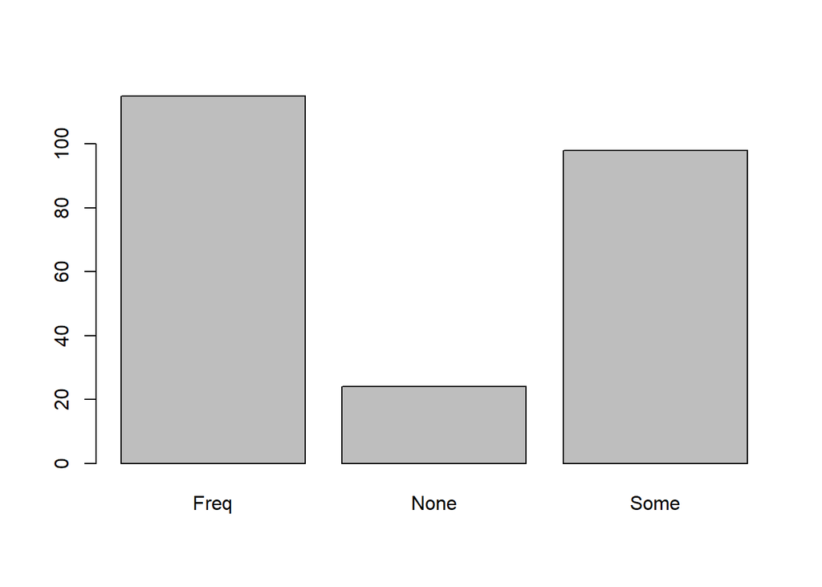

```r
> library(MASS)
> barplot(table(survey$Exer))
```

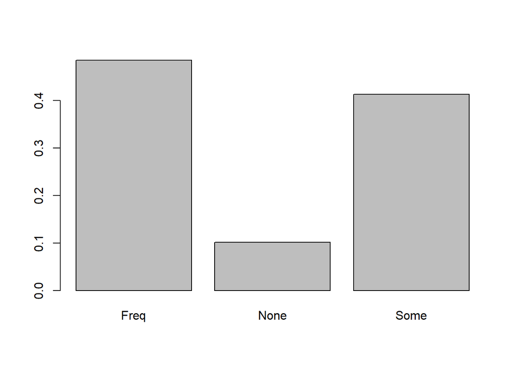

```r
> barplot(table(survey$Exer) / length(survey$Exer))
> barplot(prop.table(table(survey$Exer)))
```

```r
> barplot(proportions(table(survey$Exer)))
```

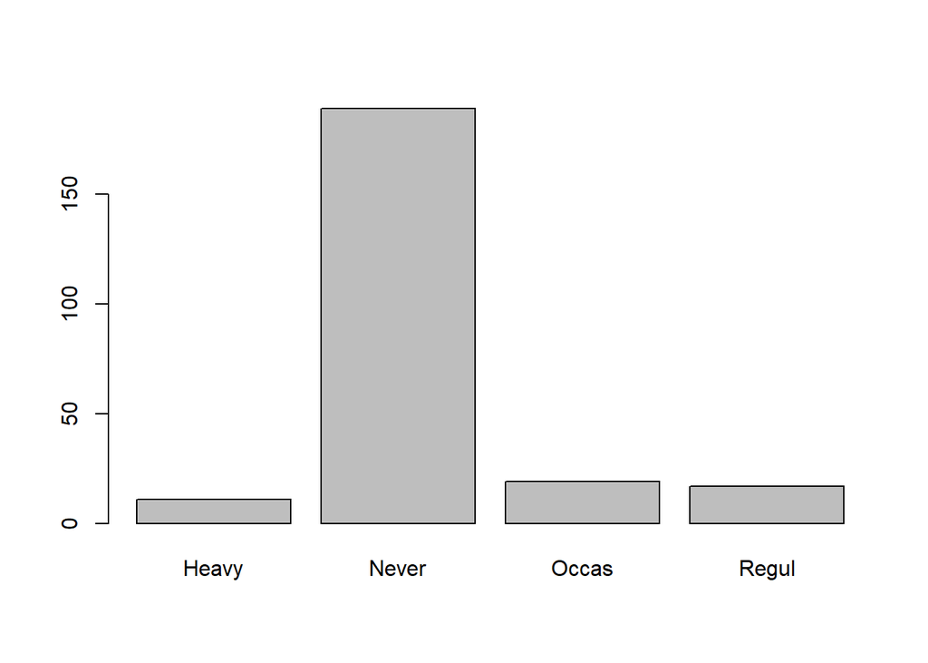

```r
> barplot(table(survey$Smoke))
```

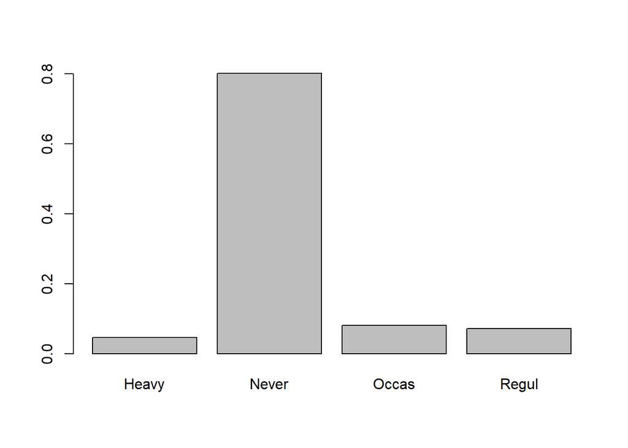

```r
> barplot(table(survey$Smoke) / length(survey$Smoke))
> barplot(proportions(table(survey$Smoke)))
> barplot(prop.table(table(survey$Smoke)))
```

It is important to notice that we are not using the `barplot` with the raw data.

We can add headers and colors to the graphics

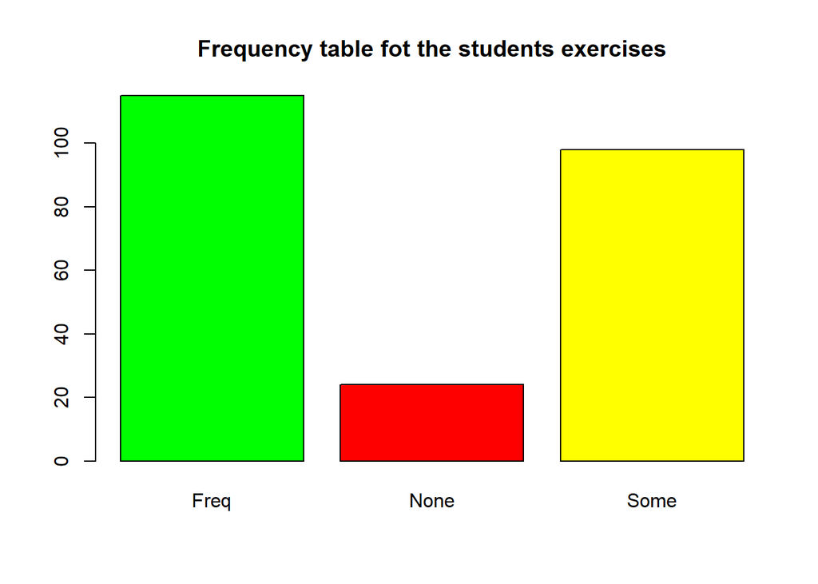

```r
> library(MASS)
> barplot(table(survey$Exer), main = "Frequency table fot the students exercises", col = c("Green", "Red", "Yellow"))
```

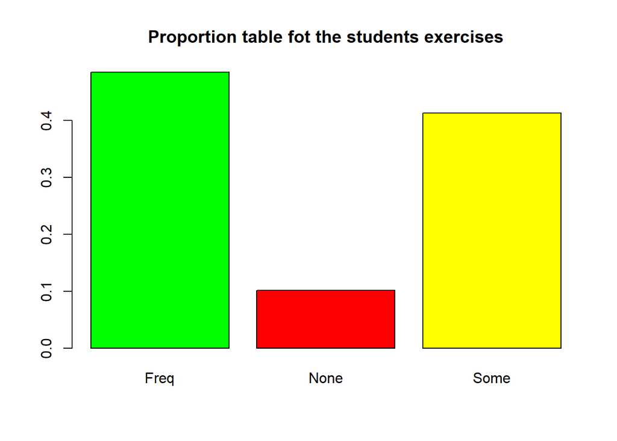

```r
> barplot(proportions(table(survey$Exer)), main = "Proportion table fot the students exercises", col = c("Green", "Red", "Yellow"))
```

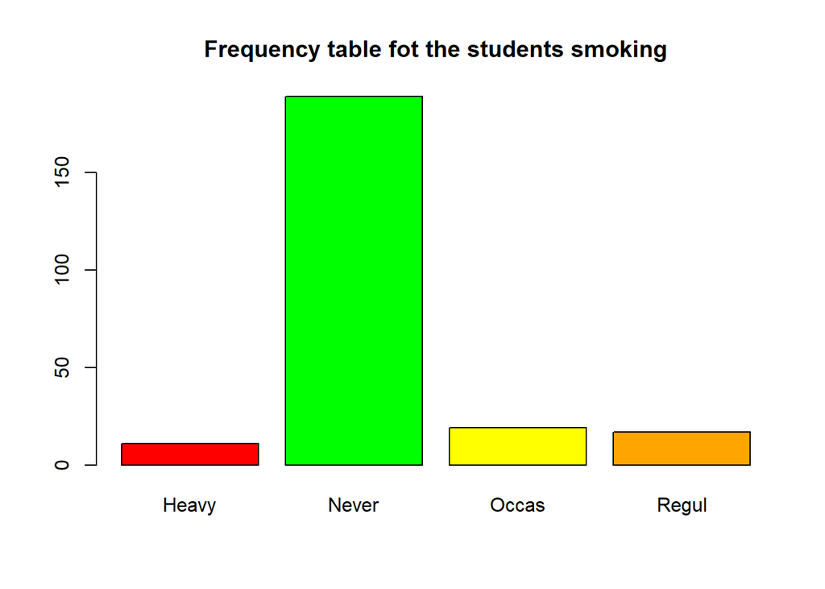

```r
> barplot(table(survey$Smoke), main = "Frequency table fot the students smoking", col = c("Red", "Green", "Yellow", "Orange"))
```

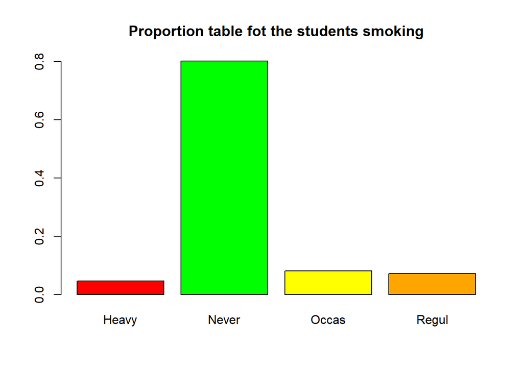

```r
> barplot(proportions(table(survey$Smoke)), main = "Proportion table fot the students smoking", col = c("Red", "Green", "Yellow", "Orange"))
```

There are a lot of other options that you can see to this graphs, you can see them from the help.

### Pie chart

Pie chart draws a circle in which every category is presented as part of this circle.

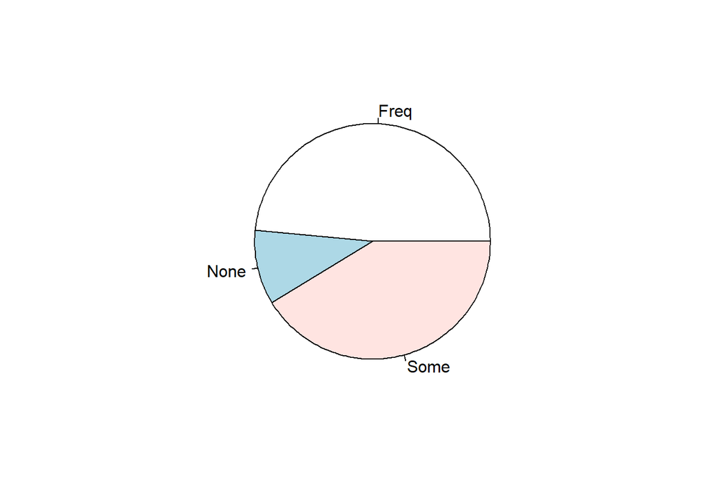

```r
> pie(table(survey$Exer))
```

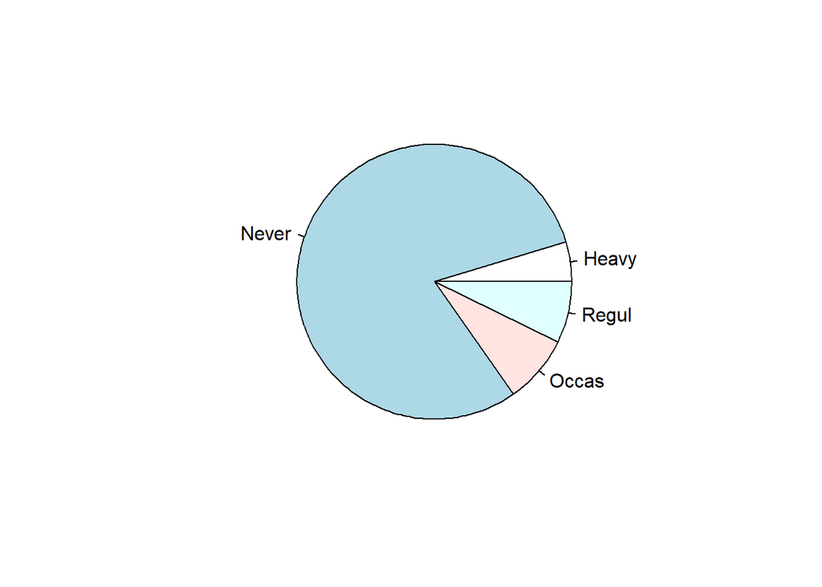

```r
> pie(table(survey$Smoke))
```

It is important to notice that we are not using the `pie` with the raw data.

We can add headers and colors to the graphics

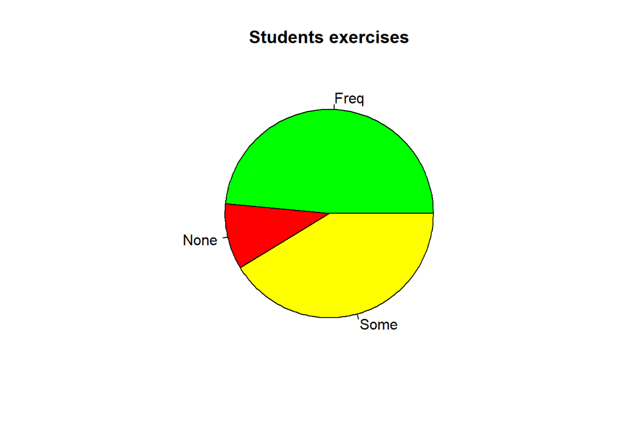

```r
> pie(table(survey$Exer), main = "Students exercises", col = c("Green", "Red", "Yellow"))
```

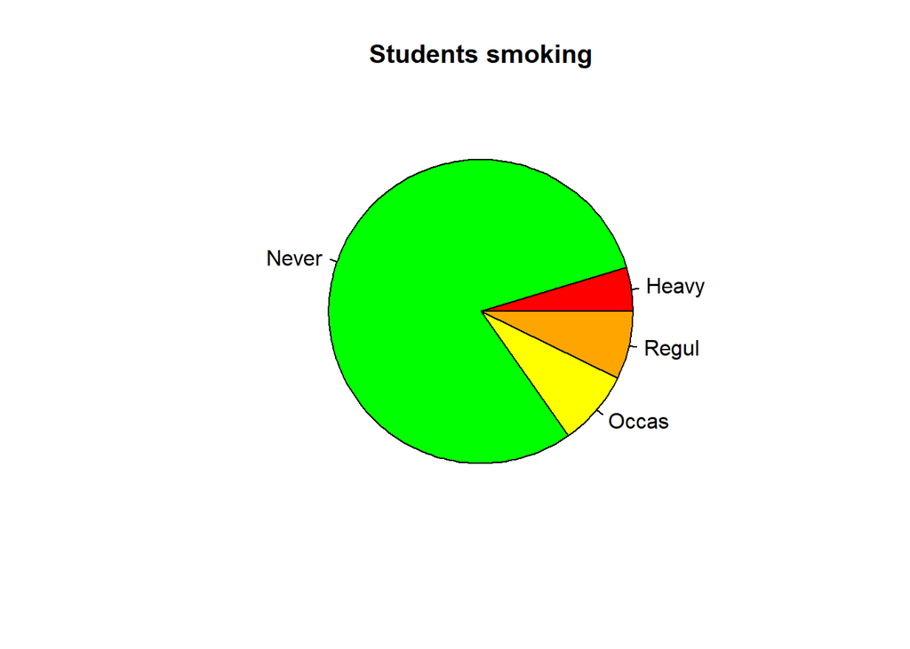

```r
> pie(table(survey$Smoke), main = "Students smoking", col = c("Red", "Green", "Yellow", "Orange"))
```

There are a lot of other options that you can see to this graphs, you can see them from the help.

## Numerical data

To describe a distribution we often want to know where is its center and what is its spread. These are typically measured by mean and variance(or standard deviation). We have already reviewed some of the functions in the Statistics tab, but let’s see some more details and examples.

```r
> min(survey$Age)
[1] 16.75
> max(survey$Age)
[1] 73
> range(survey$Age)
[1] 16.75 73.00
```

We see that the Age of the students in the survey are between 16.75 and 73 years old.

```r
> mean(survey$Age)
[1] 20.37451
> median(survey$Age)
[1] 18.583
> quantile(survey$Age, 0.25)
   25%
17.667
> quantile(survey$Age, 0.75)
   75%
20.167
> summary(survey$Age)
   Min. 1st Qu.  Median    Mean 3rd Qu.    Max.
  16.75   17.67   18.58   20.37   20.17   73.00
> fivenum(survey$Age)
[1] 16.750 17.667 18.583 20.167 73.000
```

We see that the average age of the students in the survey is 20.37. We see that 25% of the student are under age of 17.67, 50% of the students are under age of 18.58 and 75% of the students are under age of 20.17.

We can also see the trimmed mean

```r
> mean(survey$Age, trim=10/237)
[1] 19.37985
```

Standard deviation of the age of the students taking place in the survey is 6.47

```r
> sd(survey$Age)
[1] 6.474335
> var(survey$Age)
[1] 41.91701
```

The standard deviation and the variance are also sensitive to outliers. Resistant measure of spread includes the IQR and the MAD.

```r
> IQR(survey$Age)
[1] 2.5
> mad(survey$Age)
[1] 1.605656
```

### Stem and leaf chart

When the data set is really small we can use the stem and leaf diagram to see the shape of the distribution and the values. The number on the left of the bar is the stem and the number on the right is the digit. We must put them together to find the observation.

```r
> stem(survey$Age)

  The decimal point is 1 digit(s) to the right of the |

  1 | 77777777777777777777777777777777777777777788888888888888888888888888+80
  2 | 000000000000000000000000011111111111111112222333333444444
  2 | 5677999
  3 | 1133
  3 | 667
  4 | 0244
  4 |
  5 |
  5 |
  6 |
  6 |
  7 | 03
> stem(survey$Age, scale = 5)

  The decimal point is at the |

  16 | 8999
  17 | 00111111122222222222333333333444444444555555555555566667777778888888
  18 | 0000011122222223333333333444445555555566666777778888889999999
  19 | 00001122222333333334457778889999
  20 | 00011222233334578889
  21 | 0011222334569
  22 | 389
  23 | 013456678
  24 | 27
  25 | 5
  26 | 5
  27 | 3
  28 | 56
  29 | 1
  30 | 78
  31 |
  32 | 78
  33 |
  34 |
  35 | 58
  36 | 6
  37 |
  38 |
  39 | 8
  40 |
  41 | 6
  42 |
  43 | 8
  44 | 3
  45 |
  46 |
  47 |
  48 |
  49 |
  50 |
  51 |
  52 |
  53 |
  54 |
  55 |
  56 |
  57 |
  58 |
  59 |
  60 |
  61 |
  62 |
  63 |
  64 |
  65 |
  66 |
  67 |
  68 |
  69 |
  70 | 4
  71 |
  72 |
  73 | 0
```

### Histogram

If there is more data. The most common graphic is the histogram `hist`. It defines a sequence of breaks and then counts the number of observations in the bins formed by the breaks. Plotting these with a bar similar to the bar chart, but the bars are touching. The height can be the frequencies, or the proportions.

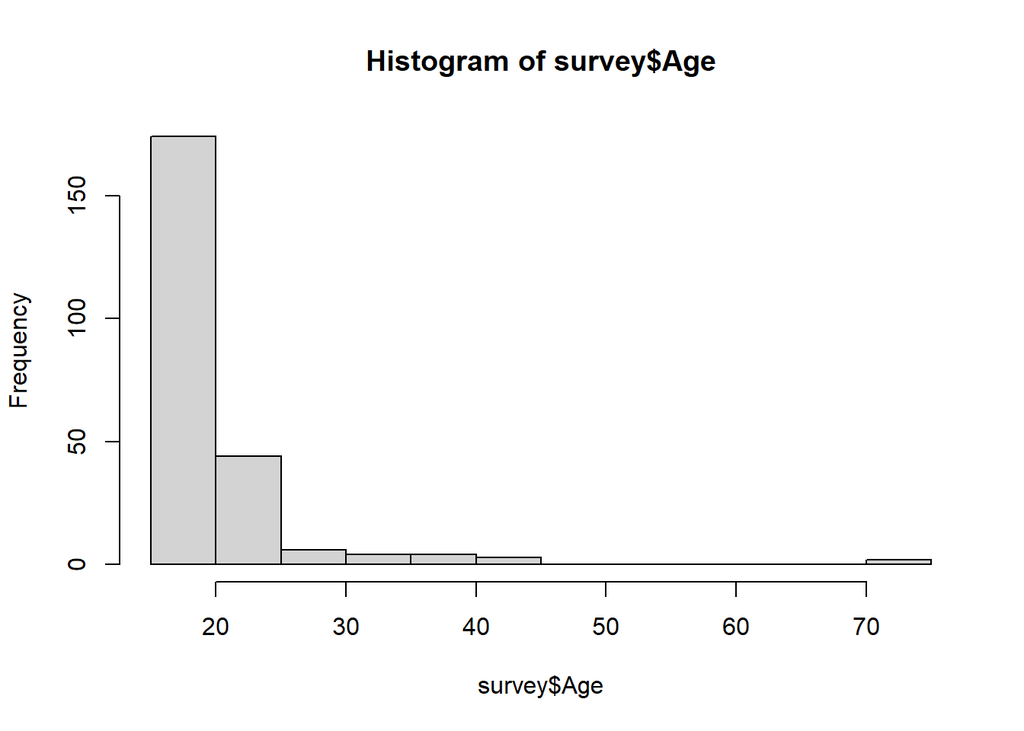

```r
> hist(survey$Age)
```

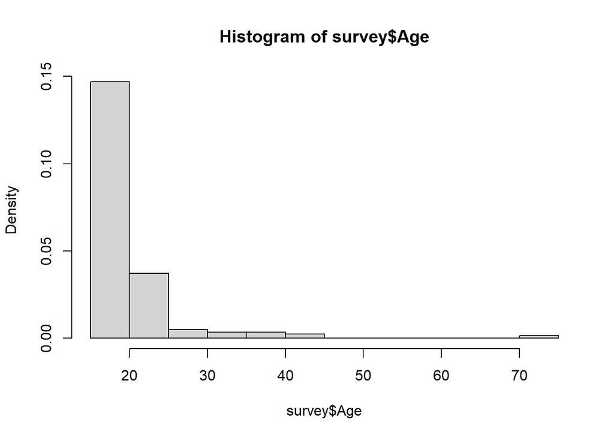

```r
> hist(survey$Age, probability = TRUE)
```

We can specify our own number of breaks or break points.

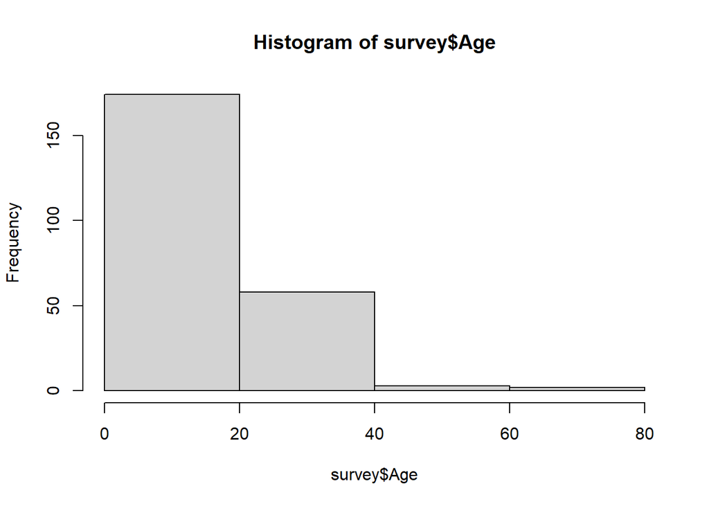

```r
> hist(survey$Age, breaks = 4)
```

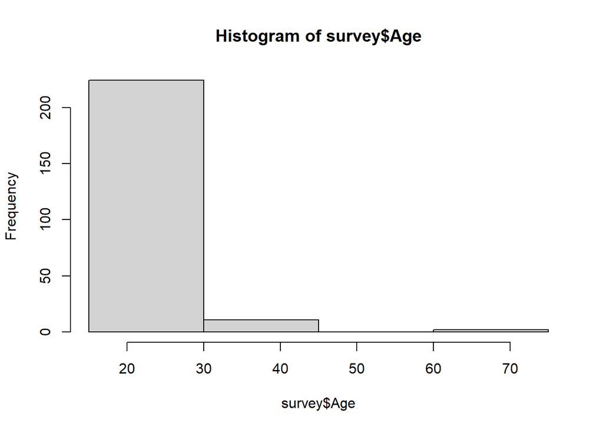

```r
> hist(survey$Age, breaks = c(15, 30, 45, 60, 75))
```

We can use `rug` function to represent the data to the plot

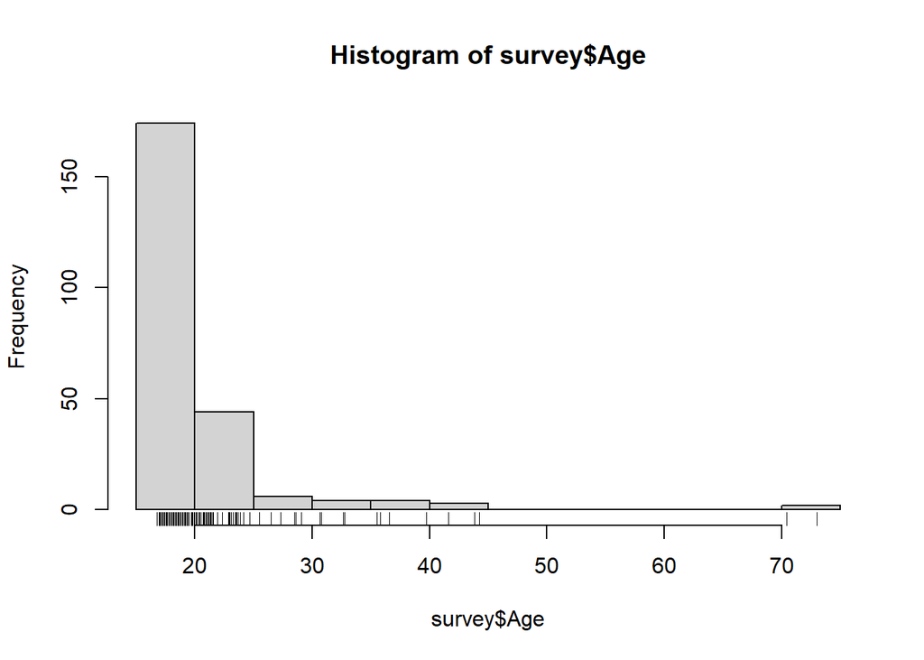

```r
> hist(survey$Age)
> rug(survey$Age)
```

and we can use `jitter` to add small amount of noise to the numeric vector, so we can see the overlapping dots.

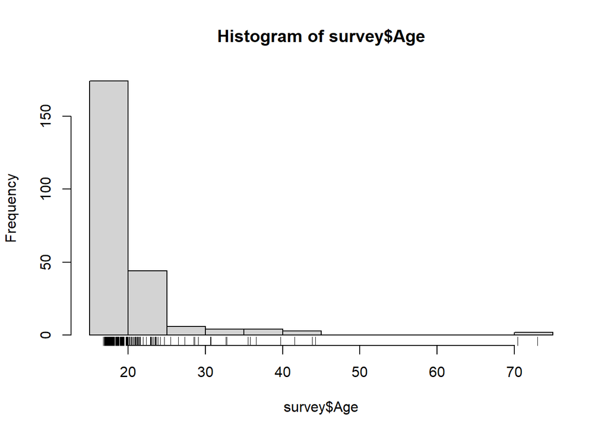

```r
> head(survey$Age)
[1] 18.250 17.583 16.917 20.333 23.667 21.000
> head(jitter(survey$Age))
[1] 18.24761 17.59779 16.91153 20.34227 23.66155 20.99132
> hist(survey$Age)
> rug(jitter(survey$Age))
```